# Using Shiny for Sports Analytics

Jack Davis

2025-05-08

# Packages

It’s all shiny today

```r
library(tidyverse)
```

```r
library(shiny)

library(ggplot2)
library(sportyR)
```

# The tradeoff of interactivity

Design difficulties and considerations.

- There is an additional design challenge with interactive graphs is that you need to show some initial visualization that’s informative, AND make it clear to the reader that the visualization can be manipulated and how to do it.
- In other words, the controls ALSO have to be clear.
- What they remember, might not be what you intend to show.
- If there are 500 players in a league (and thus 500 facets in your visualization), it’s not feasible to check each one of these for story potential.
- It’s barely feasible to check each one for errors (e.g. a special character in a name, or a player that takes zero shots and causes a division-by-zero error).
- If you want to talk about certain players or highlight certain elements, you need to make those players or objects the default visualization settings.

[figure not shown]

# Gallery: Swim Map

Demo:

https://shiny.rstudio.com/gallery/ncaa-swim-team-finder.html

App: https://gpilgrim.shinyapps.io/SwimmingProject-Click/

Code: https://github.com/gpilgrim2670/SwimMap

From the Github readMe:

`SwimMap` contains all the results from the 2018-2019 NCAA swimming season, combined with US News and World Report rankings and other information for all schools, and Google Maps data about the location of each school.

The intent is to allow an athlete who is considering swimming in college to search for schools that fit them athletically, academically, financially and with respect to location.

# Gallery: Swim Map

***The Program Finder Tab**

As such one can search for schools with a desired range of performances in a given race, with a certain range of tuition costs, and academic rankings within regions of the US and see what’s available. The Program Comparisons Tab

Similarly one can compare the range of times in a given race across several candidate schools and also view tuition costs, rankings etc. The Division Comparisons Tab

Here one can see a breakdown of each division (I, II, III) by school type and read a brief discussion on scholarship rules for each.

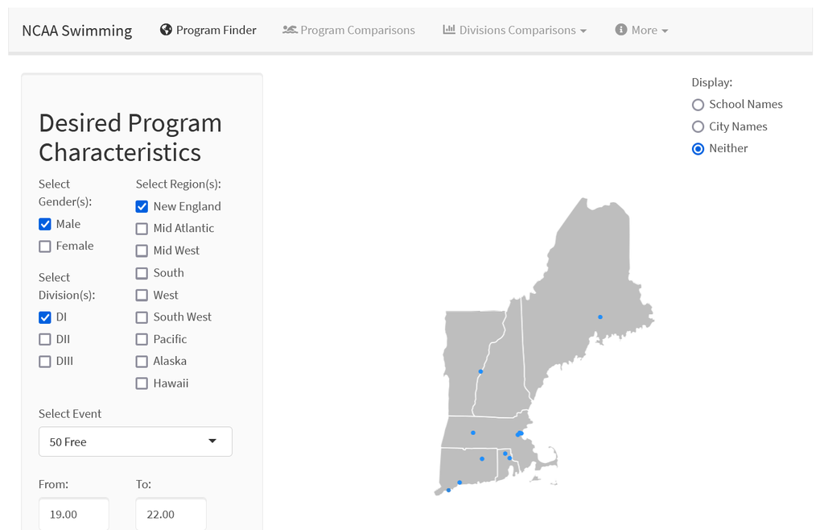

# Gallery: Swim Map

The bottom of this tab has an interactive table of the best swimmers in the relevant area.

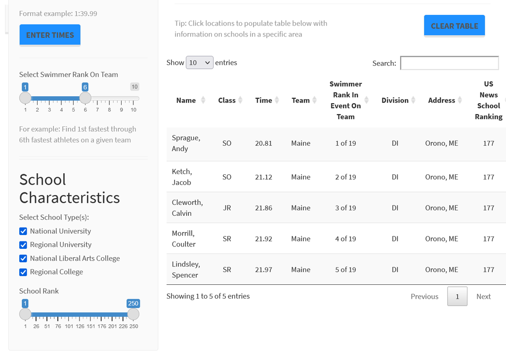

# Gallery: Swim Map

Here it is all as one image. This first tab is by far the most elaborate. It’s where the designer wants the user to spend most of their time, including their first impressions.

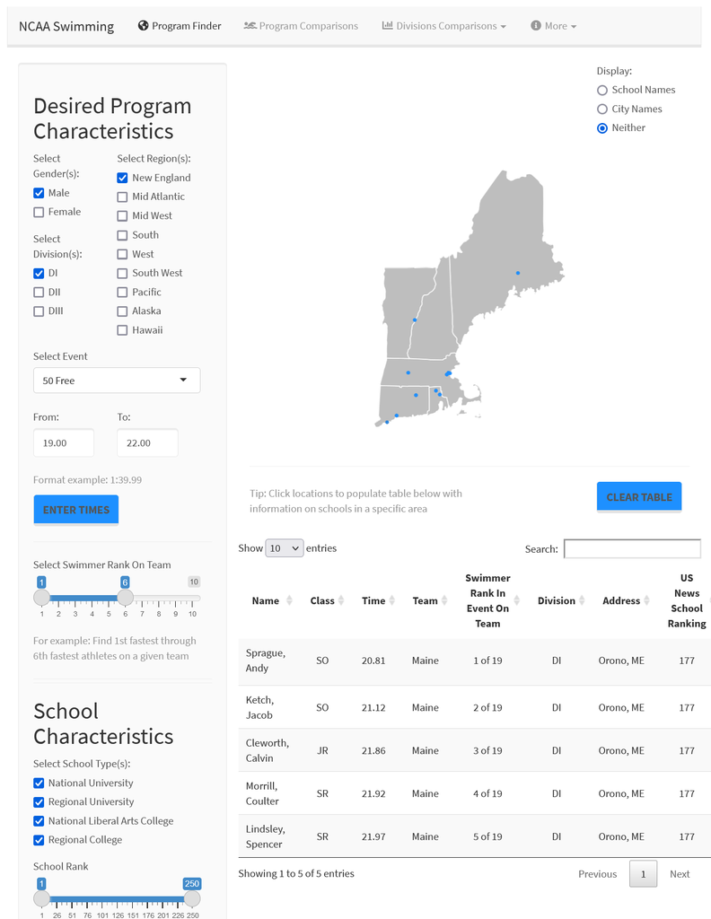

# Gallery: Swim Map

The Program Comparisons tab allows users/readers to compare swimming performance in specific events for a small selection of schools. It also has other comparitors between programs like tuition costs.

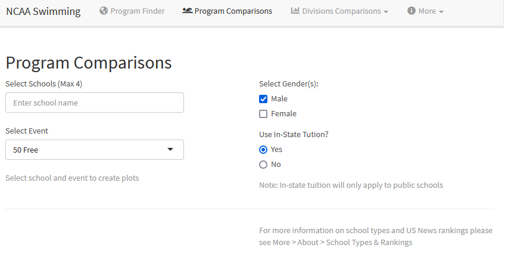

# Gallery: Swim Map

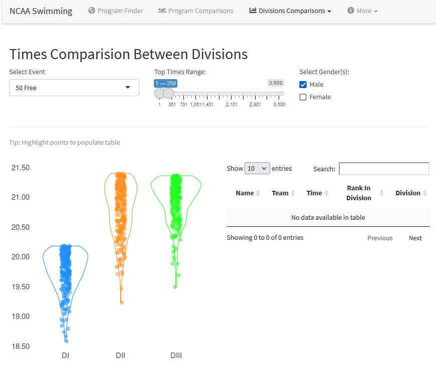

# Gallery: Swim Map

The Division Comparison tab has a pulldown menu showing a pie chart of things like the type of school in each division.

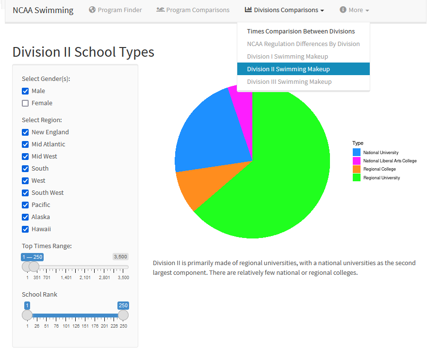

# How to be Shiny

A tour of https://shiny.rstudio.com/tutorial/

https://shiny.rstudio.com/tutorial/written-tutorial/lesson1/

Structure of a Shiny App

Shiny apps are contained in a single script called `app.R`. The script `app.R` lives in a directory (for example, `newdir/`) and the app can be run with `runApp("newdir")`.

`app.R` has three components:

- `ui`, a user interface object
- a server function
- a call to the shinyApp function

The user interface (ui) object controls the layout and appearance of your app. The server function contains the instructions that your computer needs to build your app. Finally the shinyApp function creates Shiny app objects from an explicit UI/server pair.

# How to be Shiny

Try any of these examples in the R Studio Console. If you are having trouble communicating with Localhost, `127.0.0.1`, reset you computer (not sleep mode, a full reset like a system update) and try again.

```r
# eval = FALSE, won't work inside a presentation
library(shiny)

runExample("01_hello")      # a histogram
runExample("02_text")       # tables and data frames
runExample("03_reactivity") # a reactive expression
runExample("04_mpg")        # global variables
runExample("05_sliders")    # slider bars
runExample("06_tabsets")    # tabbed panels
runExample("07_widgets")    # help text and submit buttons
runExample("08_html")       # Shiny app built from HTML
runExample("09_upload")     # file upload wizard
runExample("10_download")   # file download wizard
runExample("11_timer")      # an automated timer
```

# How to be a rare pokemon colour variant

The `app.R` contains everything you need (as of Shiny version 0.10.4, you can do everything in a single `app.R` file) like this for `01_hello`.

First, the `ui` which defines what the user sees. (If you’ve ever done anything with, say, PHP, this concept of a seperate server-side and user-side processing will seem natural. For everyone else, this is going to take a moment.)

```r
# eval = FALSE

library(shiny)

# Define UI for app that draws a histogram ----
ui <- fluidPage(

  # App title ----
  titlePanel("Hello Shiny!"),

  # Sidebar layout with input and output definitions ----
  sidebarLayout(

    # Sidebar panel for inputs ----
    sidebarPanel(

      # Input: Slider for the number of bins ----
      sliderInput(inputId = "bins",
                  label = "Number of bins:",
                  min = 1,
                  max = 50,
                  value = 30)

    ),

    # Main panel for displaying outputs ----
    mainPanel(

      # Output: Histogram ----
      plotOutput(outputId = "distPlot")

    )
  )
)
```

# How to be Shiny

The server side of the processing is defined by this. All of this code is housed in a single `app.R` file.

```r
# eval=FALSE again

# Define server logic required to draw a histogram ----
server <- function(input, output) {

  # Histogram of the Old Faithful Geyser Data ----
  # with requested number of bins
  # This expression that generates a histogram is wrapped in a call
  # to renderPlot to indicate that:
  #
  # 1. It is "reactive" and therefore should be automatically
  #    re-executed when inputs (input$bins) change
  # 2. Its output type is a plot
  output$distPlot <- renderPlot({

    x    <- faithful$waiting
    bins <- seq(min(x), max(x), length.out = input$bins + 1)

    hist(x, breaks = bins, col = "#007bc2", border = "white",
         xlab = "Waiting time to next eruption (in mins)",
         main = "Histogram of waiting times")

    })

}
```

# How to be Shiny

At one level, the Hello Shiny server function is very simple. The script does some calculations and then plots a histogram with the requested number of bins.

However, you’ll also notice that most of the script is wrapped in a call to `renderPlot`.

Finally, now that `ui` and `server` have been defined, we need one last line of code in app.R to tell it actually run.

```r
# eval=FALSE

library(shiny)

# See above for the definitions of ui and server
ui <- ...

server <- ...

shinyApp(ui = ui, server = server)
```

**Your R session will be busy while the Hello Shiny app is active, so you will not be able to run any R commands. R is monitoring the app and executing the app’s reactions. To get your R session back, hit escape or click the stop sign icon (found in the upper right corner of the RStudio console panel).**

# How to be Shiny

To make your own instead of using an example, make an empty folder/directory and put an app.R file in it, and open that file in Rstudio. (Technically, the folder doesn’t have to be empty first, but it’s good practice because other supporting files like images will go there too.)

You can call the app in that folder by typing in the console `runApp("folder_name")`, assuming that the folder is within the working directory of the console.

```r
setwd("D:/WATERLOO STAT 442/Week 13 Animation and Interactivity/")

# Within this directory, I have a folder my_app_folder
# Within that folder is an app.R file that runApp() will look for.
# later, there could be other things like .png or .csv files that app.R calls

runApp("my_app_folder")
```

# How to be Shiny, Part 3

Adding widgets

You can add widgets (interactive elements) to your web page in the same way that you added other types of HTML content in Lesson 2. To add a widget to your app, place a widget function in sidebarPanel or mainPanel in your ui object.

Each widget function requires several arguments. The first two arguments for each widget are

- a name for the widget: The user will not see this name, but you can use it to access the widget’s value. The name should be a character string.
- a label: This label will appear with the widget in your app. It should be a character string, but it can be an empty string ““.

In this example, the name is “action” and the label is “Action”:

```r
actionButton("action", label = "Action")
```

See also: https://shiny.rstudio.com/gallery/widget-gallery.html

# How to be Shiny, Part 4

One more part: reactivity.

https://shiny.rstudio.com/tutorial/written-tutorial/lesson4/

First, this we need a new Shiny app, which will need its own, new directory.

Create a folder in your working directory named `census-app`. This is where we’ll save the `app.R` file that you make in this lesson.

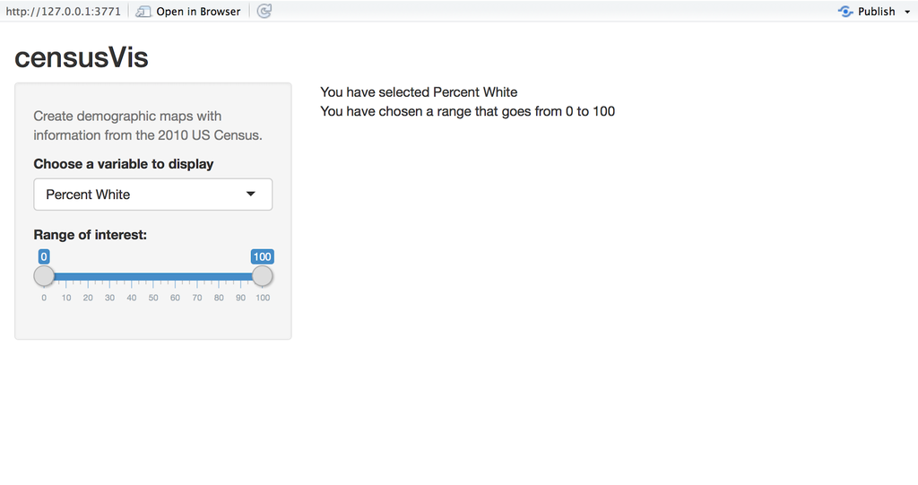

# How to be Shiny, Part 4

You can create reactive output with a two step process.

1. Add an R object to your user interface.
2. Tell Shiny how to build the object in the server function. The object will be reactive if the code that builds it calls a widget value.

Shiny provides a family of functions that turn R objects into output for your user interface. Each function creates a specific type of output.

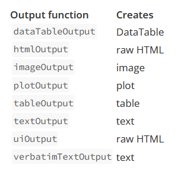

# How to be Shiny, Part 4

Now go to the `app.R` in `census-app` and look at how

- the name `my_var_name` shows up in both `select_input` in ui, and in the 1st `renderText` in server. That calls for input from the dropdown.
- the name `selected_var` shows up in the 1st `textOutput` in ui, and in the 1st `output$` in server. That’s the output returned from the server for `my_var_name`.
- the name `my_range` shows up in both `slider_input` in ui, and in the 2nd `renderText` in server. That calls for input from the both values on the slider bar.
- the name `min_max` shows up in the 2nd `textOutput` in ui, and in the 2nd `output$` in server. That’s the output returned from the server for `my_range`.

# How to be Shiny, Part 4

First try this `runApp` in console

```r
runApp("census-app")
```

Then try this `runApp` in console to show the code too

```r
runApp("census-app", display.mode = "showcase")
```

# Using ggplot in shiny.

Pull the data from the NBA database. (This eval false, because we don’t need to download a 250-400 Mb file every time)

```r
library(hoopR)
dat_pbp = load_nba_pbp(seasons = 2025)
df_pbp = data.frame(dat_pbp)
write.csv(df_pbp, "NBA_playbyplay_2025-03-27.csv", row.names=F)
```

# Using ggplot in shiny.

We’re going to grab the most recent Toronto Raptors home game again.

In the assignment I gave you the game ID, but this code block will pull the most recent Raptors home game from any play by play dataset.

We’re going to mess with this and allow you to choose a team later.

```r
df_pbp = read.csv("NBA_playbyplay_2025-03-27.csv")
target_team_name = "Toronto"

df_shots = subset(df_pbp, shooting_play == TRUE)
most_recent_date = max(df_shots$game_date
                       [df_shots$home_team_name == target_team_name])

df_1game_shots = df_shots[df_shots$game_date == most_recent_date &
                      df_shots$home_team_name == target_team_name, ]
```

# Using ggplot in shiny.

Now to make the shooting graph that we did in Assignment 3 (in Winter 2025)

```r
df_1game_shots$score_type = as.factor(df_1game_shots$score_value)

g = geom_basketball(league = "nba") +
  geom_point(data = df_1game_shots, size=3,
             aes(x=coordinate_x, y=coordinate_y,
                 color = score_type, shape=score_type)) +
  scale_shape_discrete(name = "Points scored") +
  scale_colour_discrete(guide = "none") +
  scale_size_manual(guide = "none") +
  theme(legend.position = "bottom")
```

# Using ggplot in shiny.

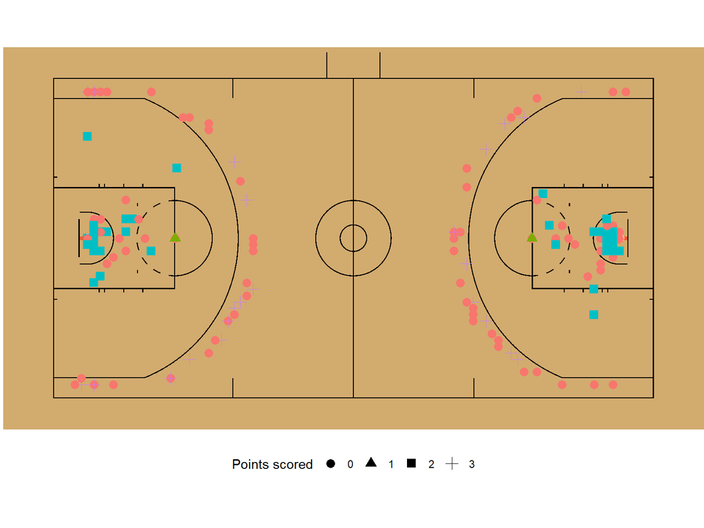

# Using ggplot in shiny.

Set up a basic UI.

```r
ui_v1 <- fluidPage(
  titlePanel("hoopR demo!!!"),

  sidebarLayout(position = "right",
                sidebarPanel("sidebar panel"),

                # Main panel for displaying outputs ----
                mainPanel(
                  plotOutput(outputId = "shotPlot")
    )
  )
)
```

# Using ggplot in shiny.

```r
# Define server logic ----
server_v1 <- function(input, output, session) {

...
  # This is basically a PNG() wrapper that sends the PNG file to the browser
  # Do this part reactively, every time the sidepanel is updated
  output$shotPlot <- renderPlot({

    # plot goes here

  })
```

# Using ggplot in shiny.

Now let’s take this graph and put it into Shiny. **Remember that the file we are loading in also needs to be in the folder with the app.R.**

(More technically, file references in app.R are relative to the folder that app.R is in, not the working directory of Rstudio)

```r
runApp("Basketball_Shots", display.mode="showcase")
```

# Using ggplot in shiny (Aside on reactivity)

https://mastering-shiny.org/basic-reactivity.html

First, input is read only to the server. You can change things that are `input` by messing with elements on the browser, but the browser is the only thing the server listens to.

```r
server <- function(input, output, session) {
  input$count <- 10
}

shinyApp(ui, server)
```

```
#> Error: Can't modify read-only reactive value 'count'
```

# Aside: Scoping

Modified from: https://shiny.posit.co/r/articles/improve/scoping/

Let’s have a look at the start of the app.R file that is making our app.

```r
library(shiny)
library(ggplot2)
library(sportyR)


df_pbp = read.csv("NBA_playbyplay_2025-03-27.csv")
```

# Aside: Scoping

```r
library(shiny)
...
```

Including `library(shiny)` at the start makes sense because it defines the `fluidPage()` function that we use to define how the user interface (UI) will operate.

The shiny package also defines the `shinyApp()` function at the end of `app.R` that we need to instantiate the app in the first place.

# Aside: Scoping

```r
...
library(ggplot2)
library(sportyR)
...
```

The commands to load the other packages into the library are also here because it’s good practice to front load the time it takes to load these packages. That is, it’s good to put as much of the heavy work into one big loading time instead of making the app laggy while it’s being used.

# Aside: Scoping

```r
...
df_pbp = read.csv("NBA_playbyplay_2025-03-27.csv")
```

That front loading is also why it’s a good idea to load any large datasets in at the beginning of `app.R` if you don’t need to reactive about file selection.

For example, when this `read.csv` line, which points to a 200+ Mb file, is put in the server function and then called by the UI with `plotOutput()` it takes so long that it prevents any other UI elements from loading after it.

# Aside: Scoping

```r
...
df_pbp = read.csv("NBA_playbyplay_2025-03-27.csv")
```

So speed is one reason to put the `read.csv` here, but there’s another, *SCOPING*.

In short, **the scope for which something is defined determines where that thing is visible**.

In this case, the data frame `df_pbp` is defined at the global environment, the highest level. It can be seen and accessed by any other code at the global level or by functions called within the global level or anything within those function (in other words, it can be accessed by anything in `app.R`)

# Aside: Scoping

```r
...
df_pbp = read.csv("NBA_playbyplay_2025-03-27.csv")
target_team_name = "Toronto"
```

That’s really useful because we can subset this in the server without worrying about it trying to load the same large CSV over and over.

Scoping is also in play in base R; if you define an object in a function, it can only be seen and used within that function and in functions called by that function. Defining something at the global environment (that is, outside of any function) makes it visible to everything.

# Dynamic UI

Consider this simple selector.

```r
 selectInput(inputId = "hometeam",
               label = "Choose your home team:",
               choices = c("Toronto", "Los Angeles", "New York")
                   ),
```

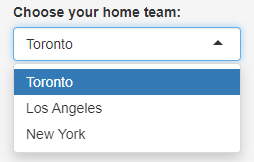

# Dynamic UI

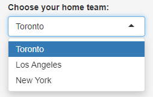

This selector is great if you only have a few options and those options will never change, and never depend on another choice you make.

However

- Teams change names and cities occasionally.
- New teams get added in expansion.
- I don’t want to write 30+ teams in manually.
- The logical choices for the away team depend upon the home team (e.g. Toronto vs. Toronto can’t happen)

# Dynamic UI

What I would like is a list of teams pulled from dataset that gets loaded in. That way I don’t have to manually load into the program what the teams are, and this would work for other leagues and other years.

What I need is a UI element that is itself reactive. Here’s how we do that.

First, I replace with the `selectInput(inputId = ...)` with a generic, UI element that ONLY specificies the inputId. Notice that it’s **uiOuput**, not **uiInput**.

```r
# Dynamic Selector (SO COOL!)
uiOutput("choose_hometeam"),
```

# Dynamic UI

Now in the server, I define the UI element of this name. Instead of `output$plot_name` or `output$table_name`, it’s `output$UI_name`.

Instead of `renderPlot`, it’s `renderUI`.

Inside the `renderUI` is a `selectInput` like we had, but now we can define the team names as a vector.

```r
 output$choose_hometeam <- renderUI({

    # Get the team names
    team_names = sort(unique(df_shots$home_team_name))

    # Create the selector
    selectInput("hometeam", "Home team whole list  DYNAMIC SELECTOR",
                       choices  = team_names,
                       selected = team_names)
  })
```

# Dynamic UI

But wait there’s more! What about the away team? What about filtering by date?

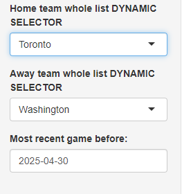

# Dynamic UI

The away team selector in the UI layer is also a uiOuput object. We’re also going to need a `dateInput` to put the `target_date` input into the server.

```r
# Dynamic Selector (SO COOL!)
uiOutput("choose_awayteam"),

# Date input for most recent game
dateInput("target_date", "Most recent game before:",
          value = "2025-04-30")
```

# Dynamic UI

In the server layer, it’s a `selectInput` object again, but we first subset the dataset based on two inputs: `hometeam` (from the first selector), and `target_date` (from the dateInput). Then anything left in the subsetted data must be a viable away team.

```r
    output$choose_awayteam <- renderUI({

    df_1team = subset(df_shots, home_team_name == input$hometeam &
                                    game_date <= input$target_date)

    # Get the team names
    team_names = sort(unique(df_1team$away_team_name))

    # Create the selector
    selectInput("awayteam", "Away team whole list DYNAMIC SELECTOR",
                choices  = team_names,
                selected = team_names)
  })
```

# Dynamic UI

Now there’s a bit of data prep work that depends upon the home team, away team, and latest date that we’re looking at. Since that’s all dependent upon our input, we need to put that prep work into something reactive.

All of this is in the server layer. Notice that all of this is in a `renderPlot` which will be named `shotPlot` for the UI layer.

```r
  output$shotPlot <- renderPlot({

    target_home_team = input$hometeam

    # Apply the team selector and target date
    df_shots2 = subset(df_shots, home_team_name == input$hometeam &
                                away_team_name == input$awayteam &
                                game_date <= input$target_date)
```

# Dynamic UI

Some more prep work, in that same `renderPlot`

```r
...
    most_recent_date = max(df_shots2$game_date
                           [df_shots2$home_team_name == target_home_team])

    df_1game_shots = df_shots2[df_shots2$game_date == most_recent_date &
                                df_shots2$home_team_name == target_home_team, ]

    df_1game_shots$score_type = as.factor(df_1game_shots$score_value)

    target_away_team = df_1game_shots$away_team_name[1]
    my_title = paste(target_away_team, target_home_team, sep=" @ ")
```

# Dynamic UI

Finally the same ggplot we had before, but with a couple more specifications. Namely, a `ggtitle` with a title specifying the teams playing Away @ Home, and the date of the game as the subtitle.

```r
...
   geom_basketball(league = "nba") +
      geom_point(data = df_1game_shots, size=3,
                 aes(x=coordinate_x, y=coordinate_y,
                     color = score_type, shape=score_type)) +
      ggtitle(label = my_title, subtitle = most_recent_date) +
      scale_shape_discrete(name = "Points scored") +
      scale_colour_discrete(guide = "none") +
      scale_size_manual(guide = "none") +
      theme(legend.position = "bottom")
  })
```

# Bracketeering

Here’s one that I miss. it shows the probability of each match outcome based on FiveThirtyEight’s Soccer Power Index, which is an Elo/Matchmaker-Rating system.

https://projects.fivethirtyeight.com/2022-world-cup-predictions/bracket/

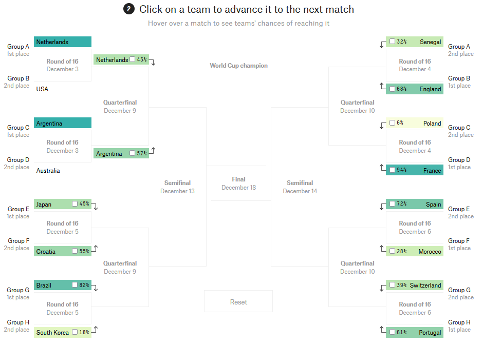

# Bracketeering

Aside from a mouseover, there are only two interactive elements: Checkboxes on each of the teams to allow you to ‘what if’ a match, and a reset button in the middle. The how-to guide is top-center.

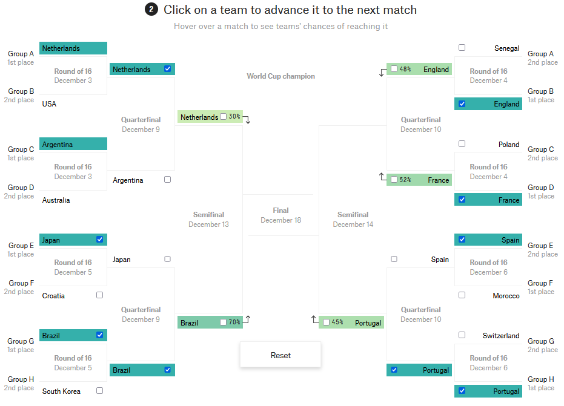

# Bracketeering

When it doesn’t know which opponent will be next, probabilities are estimated with the Law of Total Probability

$$P(A) = P(B)P(A|B) +
P(B^C)P(A|B^C)$$

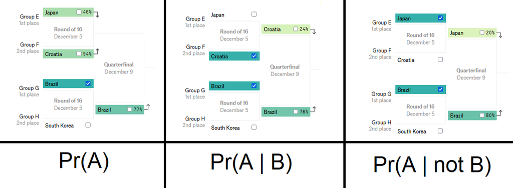

# Bracketeering

I’ve started to make my own bracket app in Shiny, but I didn’t finish it in time for this presentation

Here’s the code to draw the brackets.

First we define the final round.

```r
make_bracket_forks = function(Nrounds)
{

  ## Define this shape
  ## --------
  ##        |
  ##        |-------
  ##        |
  ## --------

  ## (0,0) to (-1,0)
  ## (-1,1) to (-1,-1)
  ## (-2,1) to (-1,1)
## (-2,1) to (-1,-1)
## Start with one fork
bracket_lines <- data.frame(x1 = c(0,-1,-2,-2),
                        y1 = c(0,1,1,-1),
                        x2 = c(-1,-1,-1,-1),
                        y2 = c(0,-1,1,-1),
                        m = 0)
...
```

# Bracketeering

Then, recursively, we take the earliest round and make two copies of it, an “upper left” copy, and a “lower left” copy.

`x_space` dictates the horizontal spacing between the forks.

```r
...

  for(k in 1:Nrounds)
  {
    # For the most recent column of forks make a new column
    # and move it to the upper-left in _u, and lower-left in _l
    add_to_brackets_u = subset(bracket_lines, m == (k-1))
    add_to_brackets_u$m =  add_to_brackets_u$m + 1
    add_to_brackets_u$x1 = add_to_brackets_u$x1 - (2 + x_space)
    add_to_brackets_u$x2 = add_to_brackets_u$x2 - (2 + x_space)
    add_to_brackets_u$y1 = add_to_brackets_u$y1 + 2^add_to_brackets_u$m
    add_to_brackets_u$y2 = add_to_brackets_u$y2 + 2^add_to_brackets_u$m

    add_to_brackets_l =  subset(bracket_lines, m == (k-1))
    add_to_brackets_l$m = add_to_brackets_l$m + 1
    add_to_brackets_l$x1 = add_to_brackets_l$x1 - (2 + x_space)
    add_to_brackets_l$x2 = add_to_brackets_l$x2 - (2 + x_space)
    add_to_brackets_l$y1 = add_to_brackets_l$y1 - 2^add_to_brackets_l$m
    add_to_brackets_l$y2 = add_to_brackets_l$y2 - 2^add_to_brackets_l$m

    bracket_lines = rbind(bracket_lines, add_to_brackets_u, add_to_brackets_l)

  } # end of for loop
...
```

# Bracketeering

Lastly, we vertically stretch the forks so that the “in” tines of one fork line up with the “out” tines of another.

```r
...

  # Stretch the tines of forks to everything lines up
  bracket_lines$y1 = bracket_lines$y1*(2^(Nrounds - bracket_lines$m))
  bracket_lines$y2 = bracket_lines$y2*(2^(Nrounds - bracket_lines$m))


  # Append the function of each of the lines of the bracket so we can put text on
  bracket_lines$loc = c("Out","Cross","InUp","InDown")
```

# Bracketeering

Some results

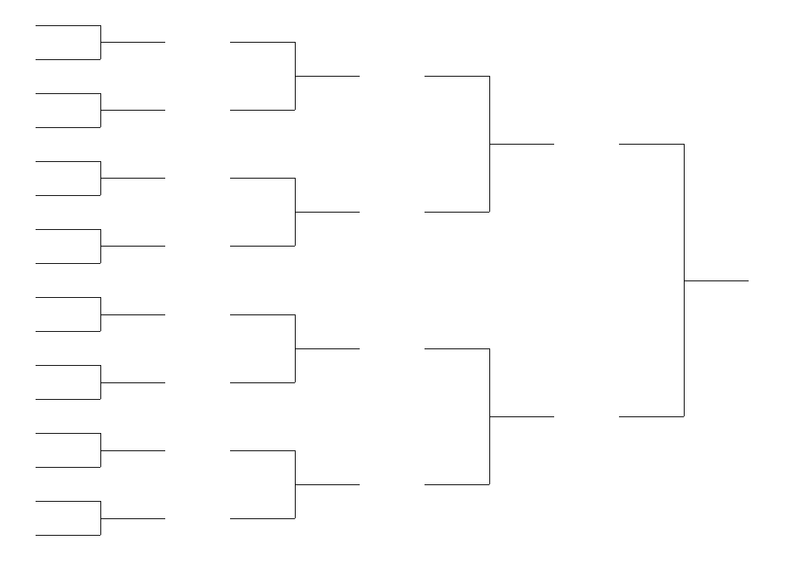

# Bracketeering

Some results

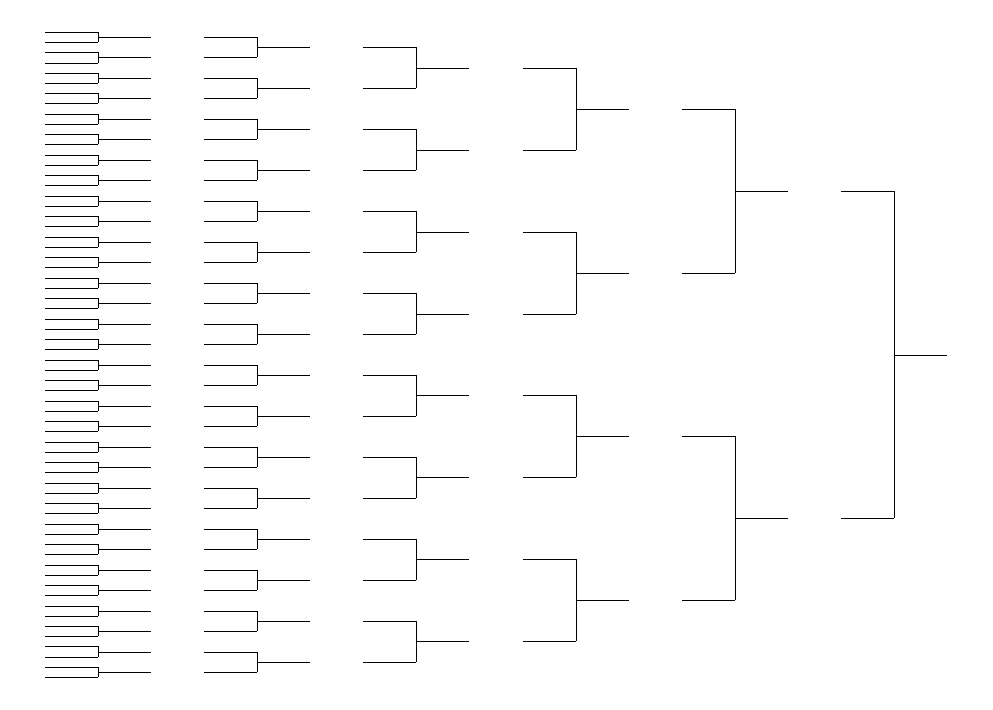

# Win Probs in the Brackets

First we need the Elo ratings. I just used an assumption that a top seed beats an 8th seed in 75% of best-of-series, give or take, and reverse engineered Elo ratings from there.

```r
# Download the round one data
dat_rd1 = read.csv("NHL_2025_Playoffs.csv")
dat_rd1
```

```
##          TeamName Round Pairing  Elo
## 1            Jets     1       1 1710
## 2           Blues     1       1 1530
## 3           Stars     1       2 1650
## 4       Avalanche     1       2 1605
## 5  Golden Knights     1       3 1680
## 6            Wild     1       3 1530
## 7           Kings     1       4 1635
## 8          Oilers     1       4 1590
## 9     Maple Leafs     1       5 1665
## 10       Senators     1       5 1545
## 11      Lightning     1       6 1620
## 12       Panthers     1       6 1560
## 13       Capitals     1       7 1695
## 14      Canadiens     1       7 1500
## 15     Hurricanes     1       8 1575
## 16         Devils     1       8 1515
```

# Win Probs in the Brackets

Augment that data frame with additional variables and placeholders for rounds

```r
dat_rdall = dat_rd1
Nrds = log(nrow(dat_rd1), base=2)
h = 10


# Augment this with additional rounds and pairings with placeholders
if(Nrds > 1)
{
for(k in 2:Nrds)
{
  TeamName = "???"
  Pairing = rep(1:(2^(Nrds - k)), each=2)
  Round = k
  Elo = NA

  dat_rdaug = data.frame(TeamName, Round, Pairing, Elo)
  dat_rdall = rbind(dat_rdall, dat_rdaug)
}

}

# Get the indicies for which calculation this is (idx)
# and the indices of the calculations that this matchup leads to
dat_rdall$idx = 1:nrow(dat_rdall)
dat_rdall$idx_next = rep(  c((1 + 2^Nrds):nrow(dat_rdall), -1), each=2)
dat_rdall$winprob = NA
dat_rdall$within_pair = 1:2


dat_rdall
```

```
##          TeamName Round Pairing  Elo idx idx_next winprob within_pair
## 1            Jets     1       1 1710   1       17      NA           1
## 2           Blues     1       1 1530   2       17      NA           2
## 3           Stars     1       2 1650   3       18      NA           1
## 4       Avalanche     1       2 1605   4       18      NA           2
## 5  Golden Knights     1       3 1680   5       19      NA           1
## 6            Wild     1       3 1530   6       19      NA           2
## 7           Kings     1       4 1635   7       20      NA           1
## 8          Oilers     1       4 1590   8       20      NA           2
## 9     Maple Leafs     1       5 1665   9       21      NA           1
## 10       Senators     1       5 1545  10       21      NA           2
## 11      Lightning     1       6 1620  11       22      NA           1
## 12       Panthers     1       6 1560  12       22      NA           2
## 13       Capitals     1       7 1695  13       23      NA           1
## 14      Canadiens     1       7 1500  14       23      NA           2
```

[output cut: 16 more lines]

# Win Probs in the Brackets

We can convert these from Elos into hypothetical win probs of any team against any other, factoring in a home team advantage $h$.

The matrix $W$ is the probability of team $i$ beating team $j$ in a series.

```r
h=10

# e = Elo
e = dat_rd1$Elo
e
```

```
##  [1] 1710 1530 1650 1605 1680 1530 1635 1590 1665 1545 1620 1560 1695 1500 1575
## [16] 1515
```

```r
# D = difference matrix
D = outer(e,e,"-")
D
```

```
##       [,1] [,2] [,3] [,4] [,5] [,6] [,7] [,8] [,9] [,10] [,11] [,12] [,13]
##  [1,]    0  180   60  105   30  180   75  120   45   165    90   150    15
##  [2,] -180    0 -120  -75 -150    0 -105  -60 -135   -15   -90   -30  -165
##  [3,]  -60  120    0   45  -30  120   15   60  -15   105    30    90   -45
##  [4,] -105   75  -45    0  -75   75  -30   15  -60    60   -15    45   -90
##  [5,]  -30  150   30   75    0  150   45   90   15   135    60   120   -15
##  [6,] -180    0 -120  -75 -150    0 -105  -60 -135   -15   -90   -30  -165
##  [7,]  -75  105  -15   30  -45  105    0   45  -30    90    15    75   -60
##  [8,] -120   60  -60  -15  -90   60  -45    0  -75    45   -30    30  -105
##  [9,]  -45  135   15   60  -15  135   30   75    0   120    45   105   -30
## [10,] -165   15 -105  -60 -135   15  -90  -45 -120     0   -75   -15  -150
## [11,]  -90   90  -30   15  -60   90  -15   30  -45    75     0    60   -75
## [12,] -150   30  -90  -45 -120   30  -75  -30 -105    15   -60     0  -135
## [13,]  -15  165   45   90   15  165   60  105   30   150    75   135     0
## [14,] -210  -30 -150 -105 -180  -30 -135  -90 -165   -45  -120   -60  -195
```

[output cut: 19 more lines]

```r
# apply home team advantage
D[upper.tri(D)] = D[upper.tri(D)] + h
D
```

```
##       [,1] [,2] [,3] [,4] [,5] [,6] [,7] [,8] [,9] [,10] [,11] [,12] [,13]
##  [1,]    0  190   70  115   40  190   85  130   55   175   100   160    25
##  [2,] -180    0 -110  -65 -140   10  -95  -50 -125    -5   -80   -20  -155
##  [3,]  -60  120    0   55  -20  130   25   70   -5   115    40   100   -35
##  [4,] -105   75  -45    0  -65   85  -20   25  -50    70    -5    55   -80
##  [5,]  -30  150   30   75    0  160   55  100   25   145    70   130    -5
##  [6,] -180    0 -120  -75 -150    0  -95  -50 -125    -5   -80   -20  -155
##  [7,]  -75  105  -15   30  -45  105    0   55  -20   100    25    85   -50
##  [8,] -120   60  -60  -15  -90   60  -45    0  -65    55   -20    40   -95
##  [9,]  -45  135   15   60  -15  135   30   75    0   130    55   115   -20
## [10,] -165   15 -105  -60 -135   15  -90  -45 -120     0   -65    -5  -140
## [11,]  -90   90  -30   15  -60   90  -15   30  -45    75     0    70   -65
## [12,] -150   30  -90  -45 -120   30  -75  -30 -105    15   -60     0  -125
## [13,]  -15  165   45   90   15  165   60  105   30   150    75   135     0
## [14,] -210  -30 -150 -105 -180  -30 -135  -90 -165   -45  -120   -60  -195
```

[output cut: 19 more lines]

```r
# W is win prob matrix. Uses Elo
W = 3^(D/200) / (1 + 3^(D/200))
round(W, 2)
```

```
##       [,1] [,2] [,3] [,4] [,5] [,6] [,7] [,8] [,9] [,10] [,11] [,12] [,13]
##  [1,] 0.50 0.74 0.59 0.65 0.55 0.74 0.61 0.67 0.57  0.72  0.63  0.71  0.53
##  [2,] 0.27 0.50 0.35 0.41 0.32 0.51 0.37 0.43 0.33  0.49  0.39  0.47  0.30
##  [3,] 0.42 0.66 0.50 0.57 0.47 0.67 0.53 0.59 0.49  0.65  0.55  0.63  0.45
##  [4,] 0.36 0.60 0.44 0.50 0.41 0.61 0.47 0.53 0.43  0.59  0.49  0.57  0.39
##  [5,] 0.46 0.70 0.54 0.60 0.50 0.71 0.57 0.63 0.53  0.69  0.59  0.67  0.49
##  [6,] 0.27 0.50 0.34 0.40 0.30 0.50 0.37 0.43 0.33  0.49  0.39  0.47  0.30
##  [7,] 0.40 0.64 0.48 0.54 0.44 0.64 0.50 0.57 0.47  0.63  0.53  0.61  0.43
##  [8,] 0.34 0.58 0.42 0.48 0.38 0.58 0.44 0.50 0.41  0.57  0.47  0.55  0.37
##  [9,] 0.44 0.68 0.52 0.58 0.48 0.68 0.54 0.60 0.50  0.67  0.57  0.65  0.47
## [10,] 0.29 0.52 0.36 0.42 0.32 0.52 0.38 0.44 0.34  0.50  0.41  0.49  0.32
## [11,] 0.38 0.62 0.46 0.52 0.42 0.62 0.48 0.54 0.44  0.60  0.50  0.59  0.41
## [12,] 0.30 0.54 0.38 0.44 0.34 0.54 0.40 0.46 0.36  0.52  0.42  0.50  0.33
## [13,] 0.48 0.71 0.56 0.62 0.52 0.71 0.58 0.64 0.54  0.70  0.60  0.68  0.50
## [14,] 0.24 0.46 0.30 0.36 0.27 0.46 0.32 0.38 0.29  0.44  0.34  0.42  0.26
```

[output cut: 19 more lines]

# Win Probs in the Brackets

The matchup probability is $m$. The matrix $S$ is the probability of each side of the matchup being a certain team.

If we know the teams, then `S[idx_h,] %*% t(S[idx_a,]))` is a matrix of 0s with a single element 1 at the appropriate matchup.

If we DON’T know the teams, then `S[idx_h,] %*% t(S[idx_a,]))` is the distribution of possible team matchups.

From the first round, we update `S` with linear interpolation of the vectors representing possible teams.

```r
m = sum((S[idx_h,] %*% t(S[idx_a,])) * W)
dat_rdall$winprob[idx_h] = m
dat_rdall$winprob[idx_a] = 1 - m


#put the probability into the next round up
# run if a team has not already been selected and if it's not the finals
S[thisidx,] = m*S[idx_h,] + (1-m)*S[idx_a,]
```

# Win Probs in the Brackets

The magic started on a toddler’s whtieboard.

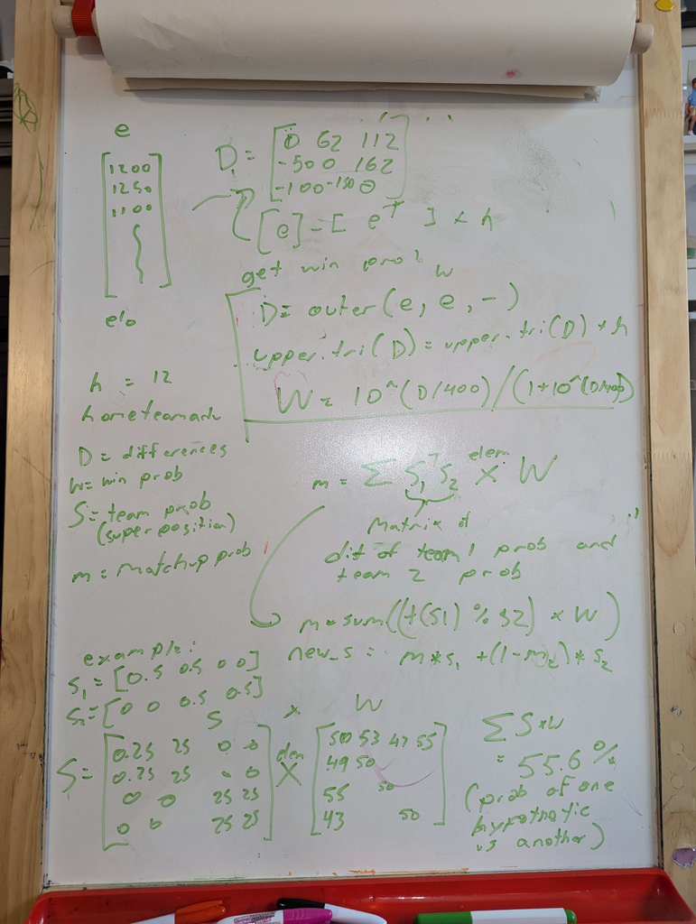

# Bracket Results

First with only the first round matchups

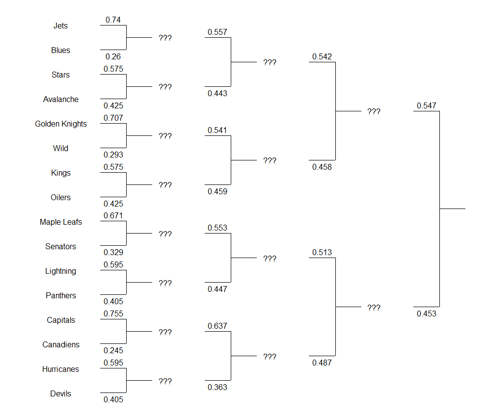

# Bracket Results

Now with half the second round

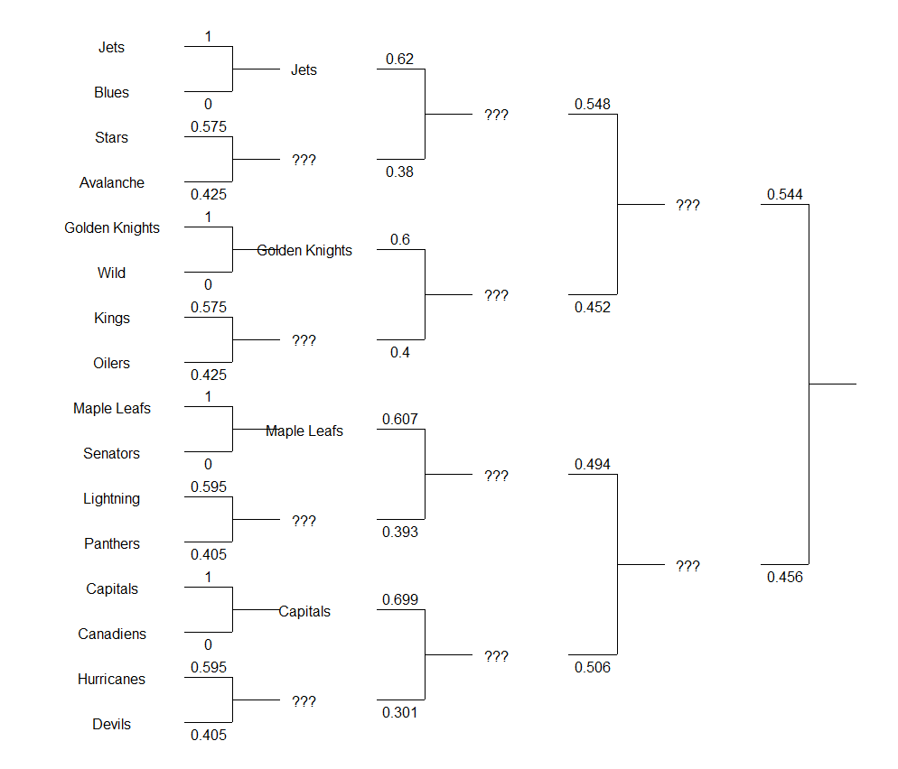

# Bracket Results

Now with all the second round

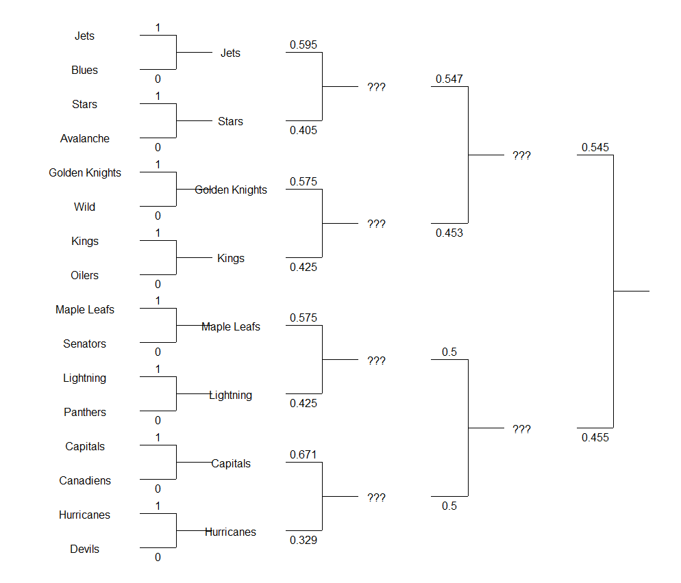